# Imputation Using Gaussian Copulas

## dummy slide

# Introduction

## Introduction Example

```r
head(dat_obs, 10)
```

```
##       X1      X2      X3    X4    X5    X6   X7   X8   X9
## 1     NA      NA -1.0154 FALSE    NA FALSE    E    E    C
## 2  0.990      NA  1.0106  TRUE  TRUE FALSE <NA>    D    B
## 3  1.213 0.71453 -1.1448    NA FALSE  TRUE <NA>    A    E
## 4  1.080 0.87564  0.0942 FALSE    NA    NA    B <NA> <NA>
## 5  0.712      NA      NA  TRUE    NA    NA    A <NA>    C
## 6  1.072 0.56038  0.3495  TRUE  TRUE  TRUE <NA> <NA> <NA>
## 7     NA 0.48548  0.4229 FALSE    NA FALSE    C    C <NA>
## 8  1.725      NA      NA    NA  TRUE  TRUE    A <NA> <NA>
## 9     NA      NA      NA FALSE FALSE    NA    A    D    D
## 10    NA 0.00989  0.8905  TRUE  TRUE    NA    A    A <NA>
```

## Copula Methods

1. Estimate the $p$ marginal cumulative distribution functions (CDFs) $\widehat F_1, \dots, \widehat F_p$.
2. Use CDFs, $\widehat F_i$s, to map to $(0, 1)^p$.
3. Make assumptions for the joint distribution on the $(0, 1)^p$ scale.

## Marginal CDFs

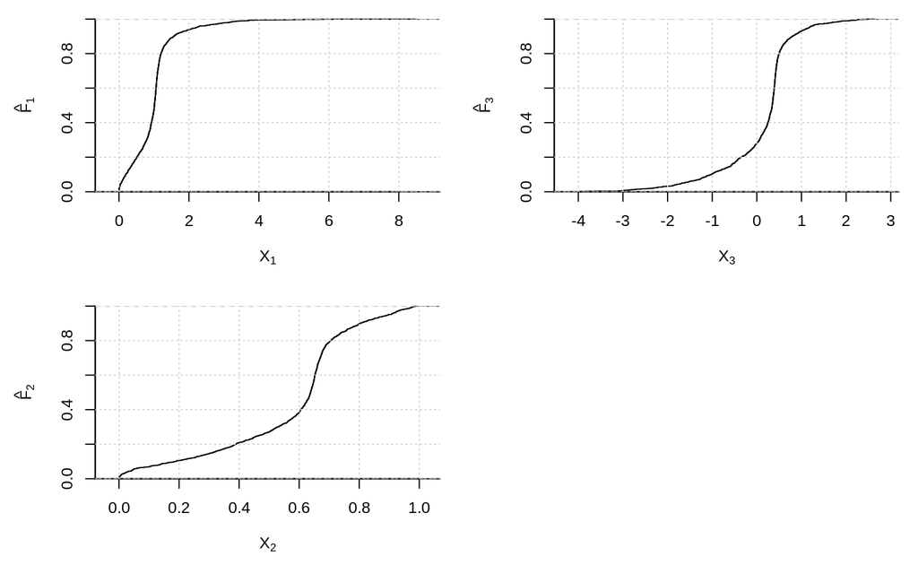

## Marginal CDFs

Continuous variables maps to a point in $(0, 1)$.

Binary/ordinal variables maps to intervals in $(0, 1)$.

Result of discretization of a hidden variable.

Make assumptions on the joint distribution of hidden variables.

## Presentation Outline

Motivation.

Show the marginal likelihood.

Show CDF approximations, gradient approximation, and imputation method.

Simulation example and simulation study.

Conclusions.

# Motivation

## Motivation

Zhao and Udell (2019) suggest a method to estimate the model.

Use approximate E-step in an EM algorithm and approximate imputation method.

Show six-fold reduction in computation time compared with the MCMC method suggested by Hoff (2007).

Show good performance compared with alternative methods.

## Critique

Zhao and Udell (2019) approximations may fail in some cases.

Direct approximation of the log marginal likelihood is possible for a moderate amount of variables ($p < 100$).

# Marginal Likelihood

## Setup

Have $\vec x_1, \dots, \vec x_n$ outcomes.

Each come from a hidden vector $\vec z_1, \dots, \vec z_n\in\mathbb{R}^p$.

$$\vec z_i \sim N^{(p)}(\vec 0, \mat C)$$

where $\mat C$ is an unknown correlation matrix.

## Continuous Variables

Continuous variable $x_{ij}$ is the result of $F_j^{-1}\circ \Phi$ applied to $z_{ij}$.

$\Phi$ is the standard normal distribution’s CDF and $F_j$ is an unknown CDF.

The inverse we will use is $\Phi^{-1} \circ \widehat F_j$.

## Ordinal/Binary Variables

Ordinal variable $j$ with $k_j$-levels is a discretization of $z_{ij}$.

It has unknown borders given by $b_{j0} = 0 < b_{j1} < b_{j2} < \cdots < b_{jk_j} = 1$.

$x_{ij}$ is the result of $F_j^{-1}\circ \Phi$ applied to $z_{ij}$ where $F_j^{-1}:\, (0, 1)\rightarrow \{1, \dots, k_j \}$ with

$$F_j^{-1}(u) = l \Leftrightarrow b_{j,l-1} < u \leq b_{jl}.$$

## Ordinal/Binary Variables

We estimate $\widehat b_{j1}, \dots, \widehat b_{j,k_j - 1}$ and define $\widehat F_j:\, \{1, \dots, k_j\} \rightarrow (0, 1)^2$ such that

$$\widehat F_j(x) = (\widehat b_{j,l - 1}, \widehat b_{jl}] \Leftrightarrow x = l.$$

Map from the level $x_{ij}$ to an interval in $\mathbb R^2$ using $\Phi^{-1} \circ \widehat F_j$

where $\Phi^{-1}$ is applied elementwise.

## Notation

Let

$$\vec x_{i\mathcal I} = (x_{il_1}, \dots, x_{il_m})^\top, \qquad \mathcal I = \{l_1, \dots, l_m\}.$$

We observe:

1. the continuous variables in $\mathcal C_i \subseteq \{1,\dots, p\}$.
2. the ordinal variables in $\mathcal O_i \subseteq \{1,\dots, p\}$.
3. miss the variables in $\mathcal M_i \subseteq \{1,\dots, p\}$.

Where $\mathcal C_i \cap \mathcal O_i = \mathcal C_i \cap \mathcal M_i = \mathcal O_i \cap \mathcal M_i = \emptyset$ and $\mathcal C_i \cup \mathcal O_i \cup \mathcal M_i = \{1, \dots, p\}$.

## Notation

Let

$$\begin{align*}\mat C_{\mathcal I\mathcal J} &=
\begin{pmatrix} c_{l_1h_1} & \cdots & c_{l_1h_s} \\
\vdots & \ddots & \vdots \\
c_{l_mh_1} & \cdots & c_{l_mh_s}\end{pmatrix},
\qquad \mathcal J = \{h_1, \dots, h_s\} \\
\widehat{\vec z}_{\mathcal C_i} &= (\Phi^{-1}(\widehat F_j(x_{ij})))_{
j \in \mathcal C_i} \\
\mathcal D_i &=
\left\{j \in \mathcal O_i: (\Phi^{-1}(\widehat b_{j,x_{ij} - 1}),
\Phi^{-1}(\widehat b_{jx_{ij}})]\right\}
\end{align*}$$

## Log Marginal Likelihood

$$\begin{align*}
L_i(\mat V) &= \log \phi^{(\lvert\mathcal C_i\rvert)}
(\widehat{\vec z}_{\mathcal C_i}; \vec 0,
\mat V_{\mathcal C_i\mathcal C_i}) +
\log\Phi^{(\lvert\mathcal O_i\rvert)}(\\
&\hspace{20pt} \mathcal D_i; \mat V_{\mathcal O_i\mathcal C_i}
\mat V_{\mathcal C_i\mathcal C_i}^{-1}\widehat{\vec z}_{\mathcal C_i},
\mat V_{\mathcal C_i\mathcal C_i} -
\mat V_{\mathcal O_i\mathcal C_i}\mat V_{\mathcal C_i\mathcal C_i}^{-1}
\mat V_{\mathcal C_i\mathcal O_i}) \\
L(\mat V) &= \sum_{i = 1}^n L_i(\mat V)
\end{align*}$$

where $\phi^{(s)}$ is a $s$-dimensional multivariate normal density and $\Phi^{(s)}$ is a $s$-dimensional multivariate normal CDF over a hypercube.

Need an approximation for the CDF.

# Approximations

## CDF Approximation

Want an approximation of

$$\Phi^{(h)}(\mathcal P; \vec\mu, \mat\Sigma) =
\int_{a_1}^{b_1}\cdots\int_{a_h}^{b_h}
\phi^{(h)}(\vec z; \vec\mu,\mat\Sigma)\der\vec z$$

for some $\mathcal P = (a_1, b_1]\times \cdots \times (a_h, b_h]$.

Use method from Genz and Bretz (2002).

Closely follow Genz and Bretz (2009).

## Separation-of-Variables

Let $\mat S$ be Cholesky decomposition of $\mat\Sigma = \mat S\mat S^\top$. Then use $\mat S\vec y + \vec \mu = \vec z$:

$$\begin{align*}
\Phi^{(h)}(\mathcal P; \vec\mu, \mat\Sigma) =
\int_{\tilde a_1}^{\tilde b_1}\phi(y_1)
\int_{\tilde a_2(y_1)}^{\tilde b_2(y_1)}\phi(y_2)
\cdots\int_{\tilde a_h(y_1, \dots, y_{h-1})}^{
\tilde b_h(y_1, \dots, y_{h-1})}
\phi(y_h)\der\vec y
\end{align*}$$

$$\tilde a_j(y_1,\dots y_{j - 1}) =
\frac{a_j - \sum_{l = 1}^{j - 1}s_{jl}y_l}{s_{jj}}$$

and $\tilde b_j$ similarly.

## Separation-of-Variables

Use $\Phi^{-1}(u_j) = y_j$:

$$\begin{align*}
\Phi^{(h)}(\mathcal P; \vec\mu, \mat\Sigma) =
\int_{\Phi(\tilde a_1)}^{\Phi(\tilde b_1)}
\int_{\Phi(\tilde a_2(\Phi^{-1}(u_1)))}^{\Phi(\tilde b_2(\Phi^{-1}(u_1)))}
\cdots\int_{\Phi(\tilde a_h(\Phi^{-1}(u_1), \dots, \Phi^{-1}(u_{h-1})))}^{
\Phi(\tilde b_h(\Phi^{-1}(u_1), \dots, \Phi^{-1}(u_{h-1})))}
\der\vec u
\end{align*}$$

## Separation-of-Variables

Re-scale and relocate with:

$$\begin{align*}
\bar a_j + (\bar b_j - \bar a_j)w_j &= u_j \\
\bar a_j(w_1, \dots, w_{j -1}) &=
\Phi(\tilde a_h(\Phi^{-1}(u_1), \dots, \Phi^{-1}(u_{j-1}))) \\
\bar b_j(w_1, \dots, w_{j -1}) &=
\Phi(\tilde b_h(\Phi^{-1}(u_1), \dots, \Phi^{-1}(u_{j-1}))) \\
\Phi^{(h)}(\mathcal P; \vec\mu, \mat\Sigma) &=
(\bar b_1 - \bar a_1)
\int_0^1(\bar b_2(w_1) - \bar a_2(w_1))\cdots \\
&\hspace{20pt}
\cdot\int_0^1(\bar b_h(w_1, \dots, w_{h - 1}) - \bar a_h(w_1, \dots, w_{h - 1}))
\int_0^1\der\vec w
\end{align*}$$

## Example with Original Integrand

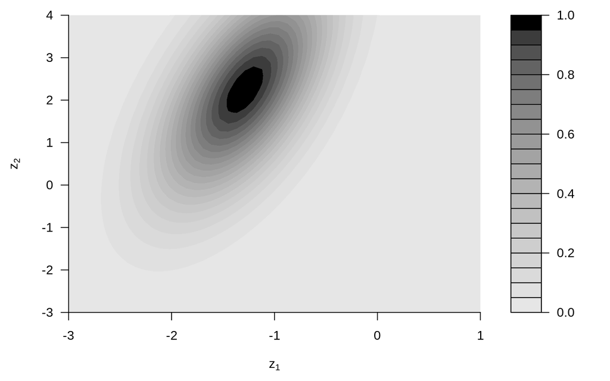

## Example with Transformed Integrand

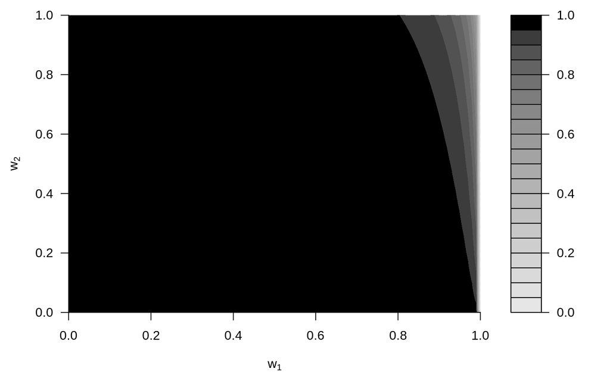

## Example with Permutated Integrand

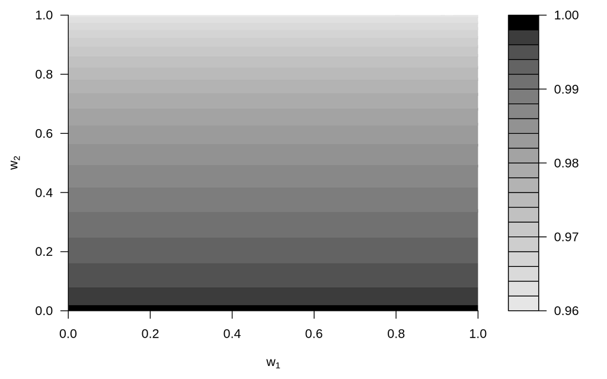

Notice the legend.

## Variable Re-ordering

A heuristic variable re-ordering can reduce the variance integrand.

## Quasi-random Numbers

Genz and Bretz (2002) use randomized Korobov rules.

Yields an error which is $\mathcal O (s^{-1}(\log s)^h)$ instead of $\mathcal O(s^{-1/2})$ where $s$ is the number samples.

## Derivatives and Imputation

Derivatives w.r.t. $\vec \mu$ and $\mat\Sigma$ and mean imputation requires:

$$\int_{a_1}^{b_1}\cdots\int_{a_h}^{b_h}
\vec h(\vec z, \vec \mu, \mat\Sigma)\phi^{(h)}(\vec z; \vec\mu,\mat\Sigma)\der\vec z$$

for some function $\vec h$.

If $\vec g:\, (0,1)^h\rightarrow \mathbb R^h$ is the map from $\vec w$ to $\vec z$ then using a transformation and permutation like before is beneficial if $\vec h(\vec g(\vec w), \vec\mu, \mat\Sigma)$ is not too variable.

## The Implementation

Extends the Fortran code By Genz and Bretz (2002).

Allows for computation in parallel.

The computation is compute-bound so this is very beneficial.

## Examples of Integral Approximations

```r
nrow(dat_obs) # number of observations
```

```
## [1] 2000
```

```r
# approximate the log marginal likelihood
mdgc_obj <- get_mdgc(dat_obs)
comp_ptr <- get_mdgc_log_ml(mdgc_obj)
mdgc_log_ml(comp_ptr, vcov = dat$Sigma, n_threads = 4L, rel_eps = 1e-3)
```

```
## [1] -14119
```

## Examples of Integral Approximations

Median running times:

|  | median |
| --- | --- |
| 1 thread | 957ms |
| 2 threads | 491ms |
| 3 threads | 353ms |
| 4 threads | 271ms |

# Simulations

## Performing Estimation and Imputation

Estimation using stochastic gradient methods.

ADAM and SVRG is implemented.

## Performing Estimation and Imputation

```r
# estimate the model and perform the imputation
set.seed(1)
system.time(
  res <- mdgc(dat_obs, lr = 1e-3, maxit = 25L, maxpts = 5000L,
              conv_crit = 1e-6, n_threads = 4L, batch_size = 100L))
```

```
##    user  system elapsed
##  24.250   0.008   6.347
```

## Imputations

```r
head(res$ximp, 3)
```

```
##     X1    X2    X3    X4    X5    X6 X7 X8 X9
## 1 1.20 0.825 -1.02 FALSE FALSE FALSE  E  E  C
## 2 0.99 0.604  1.01  TRUE  TRUE FALSE  E  D  B
## 3 1.21 0.715 -1.14  TRUE FALSE  TRUE  A  A  E
```

```r
head(dat$truth_obs, 3) # true data
```

```
##     X1    X2    X3    X4    X5    X6 X7 X8 X9
## 1 1.17 0.927 -1.02 FALSE FALSE FALSE  E  E  C
## 2 0.99 0.690  1.01  TRUE  TRUE FALSE  E  D  B
## 3 1.21 0.715 -1.14  TRUE FALSE  TRUE  C  A  E
```

## Est. Correlation Matrix

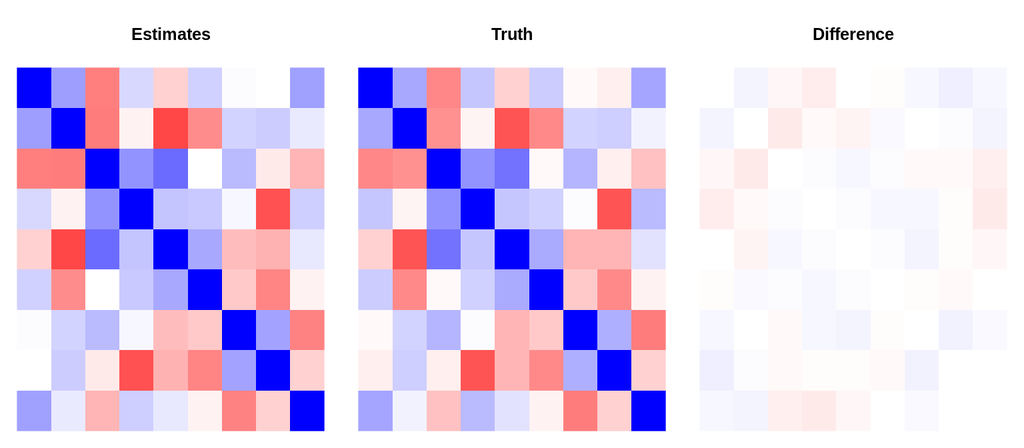

## Est. Correlation Matrix Zhao et al.

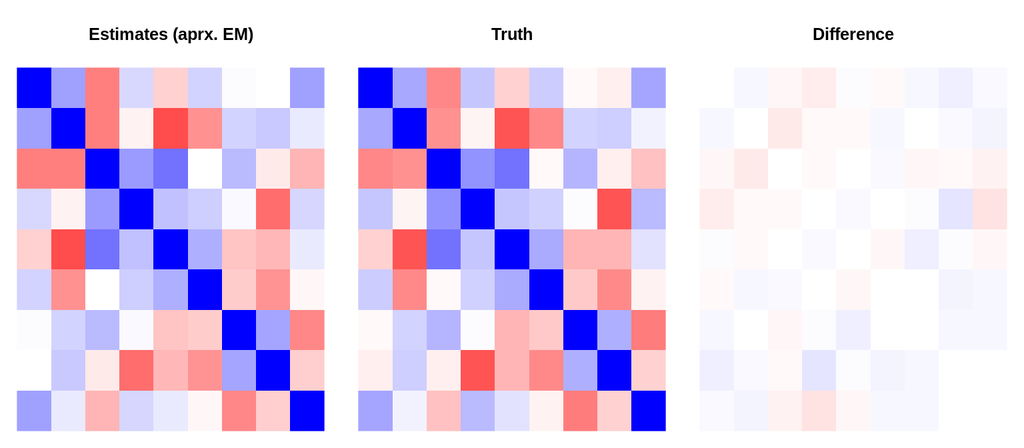

## Simulation Study

|  | Time | SE | Time (Δ) | SE | Est. error | SE | Est. error (Δ) | SE |
| --- | --- | --- | --- | --- | --- | --- | --- | --- |
| mdgc | 11.1 | 0.3 |  |  | 0.062 | 0.001 |  |  |
| mixedgc | 15.0 | 0.2 | -3.9 | 0.3 | 0.100 | 0.002 | -0.037 | 0.002 |
| missForest | 22.7 | 0.4 | -11.6 | 0.5 |  |  |  |  |

mdgc is the presented method, mixedgc is the method suggested by Zhao and Udell (2019), and missForest is the method suggested by Stekhoven and Buehlmann (2012; Stekhoven 2013). 100 samples are used in the study.

The “Est. error” is $\lVert \widehat{\mat C} - \mat C\rVert \big/\lVert\mat C\rVert$.

## Simulation Study

|  | Bin. | SE | Bin. (Δ) | SE | Ord. | SE | Ord. (Δ) | SE |
| --- | --- | --- | --- | --- | --- | --- | --- | --- |
| mdgc | 0.246 | 0.003 |  |  | 0.588 | 0.004 |  |  |
| mixedgc | 0.252 | 0.003 | -0.006 | 0.004 | 0.625 | 0.004 | -0.037 | 0.006 |
| missForest | 0.290 | 0.003 | -0.043 | 0.004 | 0.648 | 0.003 | -0.060 | 0.005 |

|  | Con. | SE | Con. (Δ) | SE |
| --- | --- | --- | --- | --- |
| mdgc | 0.465 | 0.014 |  |  |
| mixedgc | 0.469 | 0.014 | -0.005 | 0.020 |
| missForest | 0.522 | 0.015 | -0.057 | 0.021 |

Bin. is binary classification error, ord. is ordinal classification error, and con. is continuous’ variables RMSE.

## More Samples

|  | Time | SE | Time (Δ) | SE | Est. error | SE | Est. error (Δ) | SE |
| --- | --- | --- | --- | --- | --- | --- | --- | --- |
| mdgc | 151 | 5.1 |  |  | 0.081 | 0.001 |  |  |
| mixedgc | 415 | 3.4 | -263 | 6.4 | 0.115 | 0.001 | -0.034 | 0.001 |

Larger problem with $p = 60$ and $n = 10000$. 10 samples are used.

## More Samples

|  | Bin. | SE | Bin. (Δ) | SE | Ord. | SE | Ord. (Δ) | SE |
| --- | --- | --- | --- | --- | --- | --- | --- | --- |
| mdgc | 0.242 | 0.001 |  |  | 0.581 | 0.002 |  |  |
| mixedgc | 0.249 | 0.001 | -0.008 | 0.002 | 0.612 | 0.002 | -0.031 | 0.003 |

|  | Con. | SE | Con. (Δ) | SE |
| --- | --- | --- | --- | --- |
| mdgc | 0.410 | 0.013 |  |  |
| mixedgc | 0.416 | 0.013 | -0.006 | 0.019 |

# Conclusion

## Summary

Introduced Gaussian copulas method to impute missing values.

Covered quasi-random numbers method to approximate the log marginal likelihood and to perform imputations.

Showed that the method is efficient and fast even for larger problems with $p = 60$ variables.

## Extensions

Like Zhao and Udell (2020), we can use a low rank approximation:

$$\mat C = \mat W\mat W^\top + \sigma^2\mat I$$

where $\mat W\in\mathbb{R}^{p\times k}$ with $k < p$.

Easy to add prediction intervals. Probabilities of each level is already provided.

## Extensions

$x_{ij}$ is multinomial with $k_j$-categories.

Suppose

$$\begin{align*}
\vec A_{ij} &\sim N^{(k_j)}(\vec \mu_j, 2^{-1}\mat I) \\
x_{ij} &= l\Leftrightarrow A_{ijl} > A_{ijl'} \quad \forall l'\neq l
\end{align*}$$

$\vec\mu_j$ is given by the marginal distribution.

## Identity

Let

$$\Phi^{(k)}(\vec a, \vec b;\vec\mu,\mat\Sigma) =
\int_{a_1}^{b_1}\cdots\int_{a_k}^{b_k}
\phi^{(k)}(\vec x;\vec\mu,\mat\Sigma)\der\vec x$$

Then

$$\begin{align*}
\int\phi^{(k_1)}(\vec z_1; \vec\mu_1, \mat\Sigma_1)
\Phi^{(k_2)}(\vec a + \mat K\vec z_1, \vec b + \mat K\vec z_1;
\vec\mu_2,\mat\Sigma_2)\der\vec z_1 & \\
&\hspace{-200pt}=
\Phi^{(k_2)}(\vec a, \vec b; \vec\mu_2 - \mat K\vec\mu_1,
\mat\Sigma_2 + \mat K\mat\Sigma_1\mat K^\top)
\end{align*}$$

## Marginal Distribution

$$\begin{align*}
\Prob(X_{ij} = l) &= \int \phi(a;\mu_{jl},2^{-1})
\Phi^{(k_j - 1)}(-\vec\infty, \vec 1a;\vec\mu_{j(-l)}, 2^{-1}\mat I)\der a \\
&= \Phi^{(k_j - 1)}(-\vec\infty, \vec 1\mu_{jl} - \vec\mu_{j(-l)}; \vec 0,
2^{-1}\mat I + 2^{-1}\vec 1\vec 1 ^\top)
\end{align*}$$

where $\vec\mu_{j(-l)} = (\mu_{j1}, \dots, \mu_{j,l - 1}, \mu_{j,l + 1}, \dots \mu_{jk_j})$.

## Marginal Distribution (2D)

$$\begin{align*}
\Prob(X_{ij} = 1) &= \Phi(\mu_{j1} - \mu_{j2}; 0, 1) = \Phi(\mu_{j1} - \mu_{j2}) \\
\Prob(X_{ij} = 2) &= \Phi(\mu_{j2} - \mu_{j1}; 0, 1) = \Phi(\mu_{j2} - \mu_{j1})
\end{align*}$$

Select $\mu_{j2} = 0$ for identifiability:

$$\begin{align*}
\Prob(X_{ij} = 1) &= \Phi( \mu_{j1}) \\
\Prob(X_{ij} = 2) &= \Phi(-\mu_{j1})
\end{align*}$$

I.e. a binary variable with a border at $0 < \Phi(\mu_{j1}) < 1$.

## Using the Identity

Suppose $x_{ij} = l$ and write:

$$\vec V_i = (A_{ijl}, \vec A_{ij(-l)}^\top, \vec z_{i\mathcal O_i}^\top)^\top$$

where $\vec z_{i\mathcal O_i}$ are the remaining variables (ordinal/binary).

Denote:

$$\vec V_i \sim N^{(h)}\left(
\begin{pmatrix} \mu_{g} \\ \vec\mu_{(-g)}\end{pmatrix},
\begin{pmatrix} \sigma_{gg} & \vec\sigma_{g(-g)} \\
\vec\sigma_{(-g)g} & \mat\Sigma_{(-g)(-g)}\end{pmatrix}
\right)$$

## Using the Identity

The marginal likelihood factor is:

$$\begin{align*}
\int \phi(z;\mu_g;\sigma_{gg}^2) \Phi^{(h - 1)}\bigg(&\vec a_{(-g)} + \vec dz - \mat K(z - \mu_g), \vec b_{(-g)} + \vec dz - \mat K(z - \mu_g); \\
& \vec\mu_{(-g)}, \mat\Sigma_{(-g)(-g)} - \frac{\vec\sigma_{(-g)g}\vec\sigma_{(-g)g}^\top}{\sigma_{gg}}\bigg)\der z \\
\end{align*}$$

with $\mat K = \vec\sigma_{(-g)g}/\sigma_{gg}$ and

$$\vec d = (\underbrace{\,\,\,\vec 1^\top\,\,\,}_{k_j - 1\text{ times}}, \vec 0^\top)^\top$$

## Using the Identity

Thus, we get:

$$\Phi^{(h - 1)}\bigg(\vec a_{(-g)}, \vec b_{(-g)};
\vec\mu_{(-g)} - \vec d\mu_g, \mat\Sigma_{(-g)(-g)} + \vec d\vec d^\top\sigma_{gg}\bigg)$$

Easy to extend to multiple multinomial variables.

## Extending

We have $G$ categorical variables. The latent variables for the $l = 1,\dots, G$ categorical variable is at indices $r_l + 1, \dots, r_l + k_l$.

Suppose that we observe the category for the $l$th categorical variable which latent variable is at index $c_l$ and let $\mathcal C = \{c_1,\dots, c_G\}$.

## Extending

Let $\mat D = (\vec d_1, \dots \vec d_G)_{(\mathcal -C)\cdot}$, the matrix which columns are $\vec d_1, \dots, \vec d_G$ without the rows in $\mathcal C$.

Define a vector $\vec d_l = (\vec 0^\top, \underbrace{\,\,\,\vec 1^\top\,\,\,}_{k_l\text{ times}}, \vec 0^\top)^\top$ which has ones at indices $r_l + 1, \dots, r_l + k_l$.

## Extending

Then intractable integral is:

$$\begin{align*}
\int \phi^{(G)}(\vec z;\vec \mu_{\mathcal C};\mat\Sigma_{\mathcal C\mathcal C})
\Phi^{(h - G)}\bigg(\hspace{-75pt}& \\
& \vec a_{(-\mathcal C)} + \mat D\vec z -
\mat K(\vec z - \vec\mu_{\mathcal C}), \vec b_{(-\mathcal C)} +
\mat D\vec z - \mat K(\vec z - \vec \mu_{\mathcal C}); \\
& \vec\mu_{(-\mathcal C)}, \mat\Sigma_{(-\mathcal C)(-\mathcal C)} -
\mat\Sigma_{(-\mathcal C)\mathcal C}\mat\Sigma_{\mathcal C\mathcal C}^{-1}\mat\Sigma_{\mathcal C(-\mathcal C)}\bigg)
\der \vec z \\
\end{align*}$$

with $\mat K = \mat\Sigma_{(-\mathcal C)\mathcal C}\mat\Sigma_{\mathcal C\mathcal C}^{-1}$.

## Extending

Applying the identity yields:

$$\Phi^{(h - G)}\bigg(\vec a_{(-\mathcal C)}, \vec b_{(-\mathcal C)};
\vec\mu_{(-\mathcal C)} - \mat D\vec\mu_{\mathcal C},
\mat\Sigma_{(-\mathcal C)(-\mathcal C)} +
\mat D\mat\Sigma_{\mathcal C\mathcal C}\mat D^\top)$$

# Thank You!

The presentation is at rpubs.com/boennecd/Gaussian-copula-KTH.

The markdown is at github.com/boennecd/Talks.

Code and more examples at github.com/boennecd/mdgc.

References are on the next slide.

# References

Genz, Alan, and Frank Bretz. 2002. “Comparison of Methods for the Computation of Multivariate T Probabilities.” *Journal of Computational and Graphical Statistics* 11 (4). Taylor & Francis: 950–71. https://doi.org/10.1198/106186002394.

———. 2009. *Computation of Multivariate Normal and T Probabilities*. Vol. 195. Springer Science & Business Media. https://doi.org/10.1007/978-3-642-01689-9.

Hoff, P. D. 2007. “Extending the Rank Likelihood for Semiparametric Copula Estimation.” *Ann. Appl. Stat.* 1 (1). The Institute of Mathematical Statistics: 265–83. https://doi.org/10.1214/07-AOAS107.

Stekhoven, Daniel J. 2013. *MissForest: Nonparametric Missing Value Imputation Using Random Forest*.

Stekhoven, Daniel J., and Peter Buehlmann. 2012. “MissForest - Non-Parametric Missing Value Imputation for Mixed-Type Data.” *Bioinformatics* 28 (1). Oxford Univ Press: 112–18.

Zhao, Yuxuan, and Madeleine Udell. 2019. “Missing Value Imputation for Mixed Data via Gaussian Copula.”

———. 2020. “Matrix Completion with Quantified Uncertainty Through Low Rank Gaussian Copula.”